# 0.0_Carte_de_l_IA-2025

## 4 PILIERS POUR TOUS LES MODELES

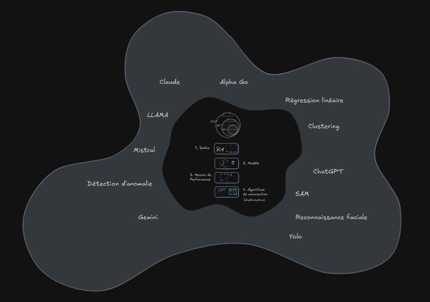

1. **Les données (Data)**

Le machine learning commence toujours par des données, quel que soit le domaine. Même en apprentissage par renforcement, la machine génère ses propres données d’expérience.

2. **Le modèle**

Un modèle sert à représenter un phénomène. Tout ce que nous allons voir (régression linéaire, clustering, ChatGPT, etc.) est un modèle, ou s’appuie sur un modèle.

3. **La mesure de performance**

Chaque domaine dispose d’une manière d’évaluer son modèle. Même en non-supervisé, on utilise des indicateurs adaptés pour mesurer la qualité de la solution.

4. **Les algorithmes de minimisation (d’optimisation**)

Ce sont eux qui permettent à un modèle d’apprendre. Ils ajustent les paramètres pour obtenir la meilleure performance possible.

**Modèle vs Algorithme** Un modèle modélise un phénomène. Un algorithme est une suite d’actions pour trouver la bonne configuration de ce modèle.

## 1. LINEAR MODELS

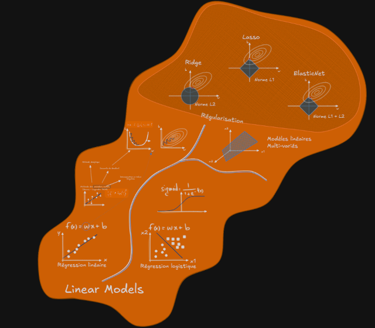

1. **Les modèles linéaires**

Ces modèles sont souvent sous-estimés, alors qu’ils résolvent aussi bien des problèmes de régression que de classification. Ils reposent sur une somme pondérée des variables, ce qui donne une représentation en forme de ligne (ou d’hyperplan en multi-dimensions).

2. **La régression linéaire**

Elle cherche le meilleur ajustement (fit) des points via la méthode des moindres carrés. Cette méthode, développée par Gauss et Legendre, minimise la distance (Euclidienne) entre la prédiction et les valeurs réelles.

3. **Les méthodes d’optimisation**

La descente de gradient est un algorithme essentiel pour trouver le minimum de la fonction coût. On peut aussi utiliser des approches analytiques ou la décomposition en valeurs singulières (SVD).

4. **La régression logistique**

C’est un “pseudo” modèle linéaire car on ajoute une fonction sigmoïde. La frontière de décision reste cependant linéaire, permettant la classification.

5. **L’extension à plusieurs variables**

On parle d’hyperplan dans un espace multidimensionnel. Malgré la présence de plusieurs dimensions, on reste dans un cadre linéaire tant que les variables ne sont pas élevées à des puissances supérieures.

6. **La régularisation (Ridge, Lasso, Elastic Net)**

Elle limite la zone dans laquelle les coefficients peuvent évoluer. Ridge applique une pénalité en forme de sphère (norme L2), Lasso une pénalité en forme de losange (norme L1), et Elastic Net combine les deux.

7. **Lutte contre l’overfitting**

En imposant une contrainte, on évite qu’un modèle avec trop de variables ne devienne trop spécialisé. Ainsi, la régularisation améliore la capacité de généralisation.

## 2. DECISION TREES

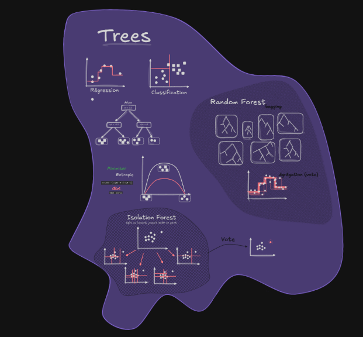

1. **Les arbres de décision**

Les arbres de décision permettent de traiter à la fois des régressions et des classifications. Ils s’appuient sur des tests successifs (if/else) pour séparer les données de façon très “carrée”, avec des frontières orthogonales.

2. **Le principe du “split”**

Un arbre de décision choisit une variable, puis vérifie si elle est supérieure (ou inférieure) à une certaine valeur. Ce découpage (split) se répète pour isoler au mieux les différents groupes.

3. **Minimiser l’entropie ou le Gini**

Les règles de découpage sont trouvées en cherchant à minimiser une fonction de coût, comme l’entropie ou le Gini. L’entropie est une mesure du désordre, issue de la thermodynamique et théorisée par Claude Shannon. L’indice de Gini mesure la pureté d’un ensemble de données.

4. **Forêts d’isolation (Isolation Forest)**

En combinant plusieurs arbres, on peut repérer les anomalies : chaque arbre vote pour déterminer quels points sont atypiques.

5. **Les random forests**

Toujours en combinant un grand nombre d’arbres générés aléatoirement, on aboutit à un vote global. Cela améliore grandement la robustesse et la précision du modèle.

6. **Une référence en industrie**

Les modèles à base d’arbres sont très puissants et largement utilisés (machine learning, data science, etc.). Même les GAFAM exploitent ces modèles pour leurs algorithmes avancés.

## 3. SUPPORT VECTOR MACHINES (SVM)

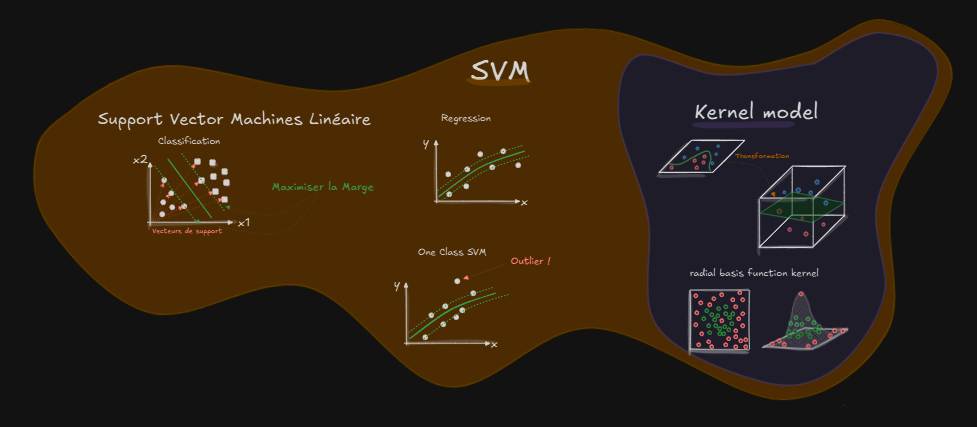

1. **Introduction aux SVM**

Les SVM, autrefois très populaires, sont moins utilisés aujourd'hui en raison de leur difficulté à se généraliser à des ensembles de données volumineux. Cependant, ils restent utiles dans certains cas spécifiques.

2. **Principe de base**

Les SVM cherchent à maximiser la marge, c'est-à-dire la distance entre les vecteurs de support des différentes classes.  
Cela revient à placer une droite (ou un hyperplan) qui sépare au mieux les classes en minimisant une fonction de coût opposée.  
Ce concept s'applique aussi bien aux problèmes de classification qu'aux régressions.

3. **Applications des SVM linéaires**
- **Classification** : Séparation des données avec une droite ou un hyperplan.
- **Régression** : Utilisation de la marge pour prédire une tendance moyenne.
- **Détection d'anomalies** : Algorithmes tels que le One Class SVM pour isoler les outliers.
4. **Kernel Trick**

Le kernel trick permet de transformer l'espace des données en ajoutant des dimensions supplémentaires.

- Exemple : Projection de points de 2D en 3D pour les rendre séparables par un hyperplan.
- Kernel RBF (Radial Basis Function) : Un des kernels les plus puissants, utilisé pour isoler des points complexes au sein d'un jeu de données.

Cependant, cette méthode est coûteuse en calcul, ce qui limite son utilisation sur de larges ensembles de données.

5. **Conclusion**

Les SVM sont des outils puissants et polyvalents, mais leur efficacité dépend de la taille des données et des transformations appliquées. Bien qu'ils soient moins adaptés aux grands volumes, ils restent pertinents pour des tâches spécifiques.

## 4. BAYESIANS MODELS

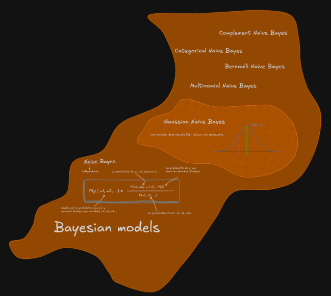

1. **L’univers bayésien**

Les modèles bayésiens reposent sur le théorème de Bayes. Ils combinent la rigueur mathématique à une approche parfois simplificatrice, comme le montre Naive Bayes.

2. **Le Naive Bayes**

Cet algorithme suppose que toutes les variables sont indépendantes entre elles. En pratique, cette hypothèse est souvent fausse (ex. taille et poids), mais le modèle fonctionne malgré tout très bien. Il calcule la probabilité qu’une classe (ex. “spam”) survienne, étant donné certaines observations (ex. nombre de mots, liens).

3. **Les variantes (Gaussian, Bernoulli, etc.)**

Selon la nature des données, Naive Bayes peut prendre une forme gaussienne, multinomiale, etc. Chaque variante adapte la façon de représenter la probabilité P(x | y).

## 5. DIMENSIONALITY REDUCTION

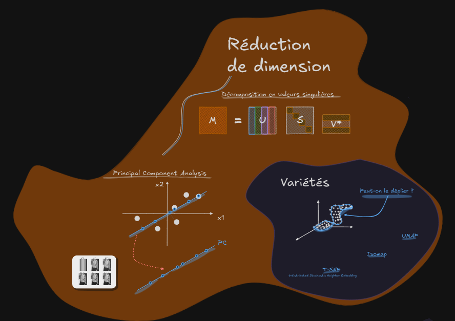

1. **Introduction à la réduction de dimension**

La réduction de dimension simplifie les jeux de données en réduisant le nombre d'attributs. Elle s'appuie souvent sur des techniques mathématiques comme la décomposition en valeurs singulières (SVD). Cette méthode décompose une matrice en trois autres matrices, facilitant les calculs et les projections.

2. **Analyse en composantes principales (PCA)**

Le PCA est un algorithme clé pour réduire la dimensionnalité. Il projette les données sur des axes principaux afin de conserver l'essentiel des informations. Exemple : Compression d'images. Une image est projetée sur 50, 40, 30, 20, 10, ou même un seul axe. Jusqu'à 20 axes, la qualité reste bonne. En dessous de 10, l'information devient insuffisante. Le PCA réduit la taille et la complexité tout en préservant un niveau acceptable de qualité.

3. **Modèles basés sur les variétés**

Les algorithmes de variétés apprennent des formes géométriques complexes appelées manifolds. Leur objectif est de simplifier ces formes tout en préservant leurs propriétés. Exemple : Modélisation d'un "S". Une forme complexe (comme un S) peut être réduite en une structure plus simple. Une fois modélisée, les axes d'origine deviennent inutiles. Il suffit de replacer la forme réduite dans l'espace. Algorithmes courants : t-SNE, UMAP, Isomap.

## 6. ENSEMBLE MODELS

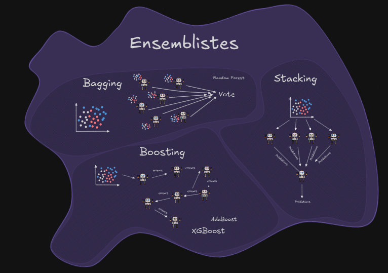

1. **Introduction aux modèles ensemblistes**

Les modèles ensemblistes regroupent plusieurs modèles pour améliorer les performances. Ces techniques sont à la base de nombreux algorithmes performants en machine learning.

2. **Bagging**

Le bagging combine le bootstrapping et l’agrégation. Le bootstrapping consiste à sélectionner aléatoirement des échantillons de données pour entraîner plusieurs modèles. Ensuite, leurs prédictions sont agrégées, souvent par un vote, pour obtenir une prédiction finale. Exemple : Random Forest, qui utilise cette méthode pour des régressions et des classifications. Analogie : Inviter plusieurs amis experts à prédire un résultat et prendre la moyenne de leurs réponses.

3. **Boosting**

Le boosting entraîne une série de modèles faibles, chacun apprenant à corriger les erreurs du précédent. Cette méthode forme une chaîne de modèles où chaque étape améliore les prédictions. Exemple : XGBoost, basé sur le Gradient Tree Boosting, est un des algorithmes les plus performants pour les données tabulaires. Analogie : Un ami débutant en investissement donne son avis, et un autre apprend à prédire ses erreurs pour affiner les recommandations.

4. **Stacking**

Le stacking combine différents modèles en envoyant leurs prédictions à un modèle final, qui apprend à produire une prédiction basée sur celles des autres. Contrairement au boosting, il ne corrige pas les erreurs mais travaille sur les prédictions. Exemple : Modèles variés combinés pour une prédiction finale plus robuste.

5. **Conclusion**

Les modèles ensemblistes, comme le bagging, le boosting et le stacking, sont puissants et largement utilisés dans des domaines tels que Kaggle ou les applications tabulaires.

## 7. NEAREST NEIGHBORS

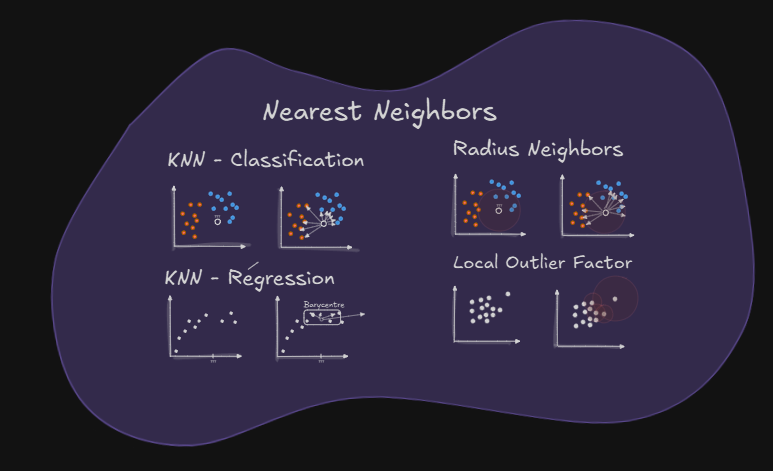

1. **Introduction aux Nearest Neighbors**

Les algorithmes des Nearest Neighbors se basent sur le calcul des distances entre les points d’un jeu de données. Ils sont simples et efficaces pour résoudre des problèmes de classification, de régression, et de détection d’anomalies.

2. **K-Nearest Neighbors (KNN)**
- **Classification** : Pour un point inconnu, on regarde ses K voisins les plus proches. La classe majoritaire parmi ces voisins est attribuée au point.

Exemple : Identifier un champignon comme toxique ou comestible en fonction des champignons voisins.

- **Régression** : Le KNN peut également prédire une valeur en prenant la moyenne (ou le barycentre) des valeurs de ses K voisins les plus proches.

Le KNN est un algorithme souvent sous-estimé mais très utile dans de nombreux cas.

3. **Radius Neighbors**

Cet algorithme est similaire au KNN, mais il restreint la recherche des voisins à un rayon donné.  
Cela permet de limiter les calculs dans des jeux de données volumineux et d'améliorer l'efficacité dans des contextes spécifiques.

4. **Local Outlier Factor (LOF)**

Le LOF est utilisé pour détecter des anomalies. Il identifie les points isolés qui ne semblent pas appartenir au groupe principal.  
Exemple : Trouver des données aberrantes ou des outliers dans un dataset dense.

5. **Conclusion**

Les Nearest Neighbors, qu’il s’agisse du KNN, du Radius Neighbor ou du Local Outlier Factor, sont des algorithmes efficaces, intuitifs et faciles à mettre en œuvre, même à grande échelle.

## 8. CLUSTERING

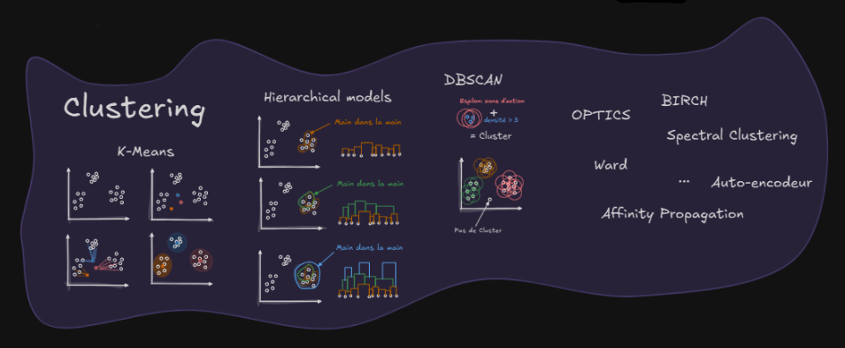

1. **Introduction au clustering**

Le clustering regroupe les données en clusters basés sur des calculs de distance ou des similarités. Il existe plusieurs algorithmes adaptés à différents cas d'usage.

2. **K-Means**

Le K-Means est un algorithme itératif qui positionne des centroïdes pour former des clusters.

- Il requiert de spécifier à l'avance le nombre de clusters.
- Les centroïdes se déplacent progressivement pour converger vers le centre des clusters.

K-Means est efficace, mais limité dans des cas où les données ne suivent pas une distribution gaussienne.

3. **Modèles hiérarchiques**

Ces algorithmes regroupent les données en suivant une structure hiérarchique.

- Chaque point se lie à son voisin pour former des petits groupes. Ces groupes se combinent ensuite pour créer des clusters plus larges.
- Avantages : Fonctionne bien avec des données ayant des formes complexes ou non gaussiennes.
4. **DBSCAN**

Le DBSCAN (Density-Based Spatial Clustering of Applications with Noise) identifie des clusters basés sur la densité des points.

- Deux hyperparamètres importants : le rayon de recherche et la densité minimale.
- Avantage : Pas besoin de spécifier le nombre de clusters à l'avance.
- Limite : Le DBSCAN de Sklearn présente des problèmes sur de grandes échelles. Attention aux performances.
5. **Autres algorithmes**
- **OPTICS** : Extension du DBSCAN pour détecter des clusters de différentes densités.
- **Spectral Clustering** : Basé sur les graphes pour trouver des clusters.
- **BIRCH** et **Affinity Propagation** : Adaptés pour de très grandes bases de données.
- Des modèles basés sur des réseaux de neurones, comme les auto-encodeurs, sont également utilisés dans des contextes avancés.
6. **Conclusion**

Le choix de l'algorithme de clustering dépend de la structure des données et des besoins spécifiques. Certains algorithmes comme les modèles hiérarchiques ou le DBSCAN offrent une flexibilité supérieure pour des formes de clusters non standards.

## 9. AUTO-REGRESSION

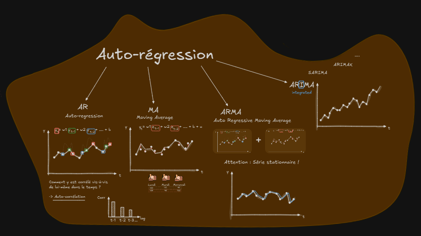

1. **Introduction aux modèles d'autorégression**

Les modèles d'autorégression sont couramment utilisés pour les séries temporelles. Bien que moins populaires aujourd'hui avec l'avènement du deep learning, ils restent pertinents grâce à leur élégance mathématique et leur capacité à modéliser les dépendances dans le temps.

2. **Modèle AR (Auto-Regressive)**

Le modèle AR prédit la valeur actuelle d'une série en fonction des valeurs passées.

- Exemple : Prédire le nombre de passagers aériens cette semaine en fonction des données des semaines précédentes.
- Le principe repose sur la corrélation temporelle entre les valeurs passées et actuelles.

Si les valeurs passées influencent significativement le présent, elles sont sélectionnées pour le calcul.

3. **Modèle MA (Moving Average)**

Le modèle MA prédit une valeur en se basant sur les erreurs des prédictions passées.

- Exemple : Un boulanger ajuste le nombre de baguettes produites chaque jour en fonction des écarts entre la demande réelle et ses prévisions.

Ce modèle affine continuellement ses prédictions pour réduire les erreurs.

4. **Modèle ARMA (Auto-Regressive Moving Average)**

L'ARMA combine les concepts des modèles AR et MA.

- Il est particulièrement efficace pour les séries stationnaires, où la moyenne et la variance sont stables dans le temps.

Attention : Ces modèles ne conviennent pas aux séries non stationnaires présentant des tendances ou des variations saisonnières.

5. **Extensions : ARIMA, SARIMA, etc.**
- **ARIMA** intègre la différenciation pour traiter les séries non stationnaires.
- **SARIMA** ajoute des composantes saisonnières pour modéliser les tendances périodiques.

Ces variantes permettent de gérer une plus grande variété de séries temporelles complexes.

6. **Conclusion**

Les modèles d'autorégression (AR, MA, ARMA, et leurs extensions) offrent une base solide pour l'analyse des séries temporelles. Ils restent une alternative intéressante, surtout dans des contextes où des modèles plus simples sont suffisants ou préférables.

## 10. ARTIFICIAL NEURAL NETWORKS (ANN)

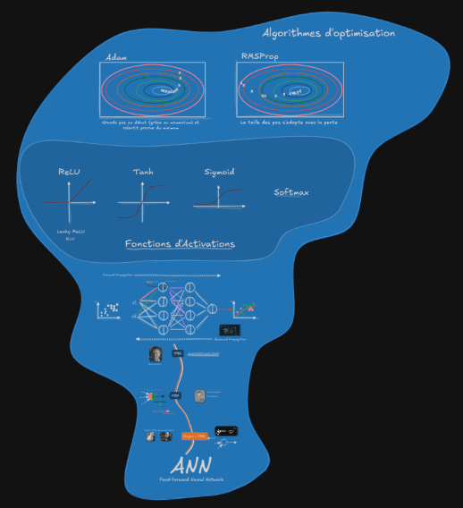

1. **Origines et fondations**

Les Artificial Neural Networks (ANN), ou réseaux de neurones artificiels, trouvent leur origine en 1943 grâce à Walter Pitts et Warren McCulloch.  
Ils ont modélisé un neurone biologique avec des entrées, un calcul interne, et une sortie.  
En 1957, Frank Rosenblatt a introduit le perceptron, en ajoutant une fonction d’activation échelon.  
Cependant, cette version a montré ses limites face à des problèmes comme le XOR, ce qui a mené à une période d’inactivité dans le domaine.  
Le perceptron multicouche, développé par Geoffrey Hinton et son équipe, a relancé l’intérêt pour les réseaux de neurones.  
Il connecte plusieurs couches de neurones et utilise l'algorithme de backpropagation pour ajuster les paramètres.

2. **Fonctions d'activation**

Les fonctions d'activation jouent un rôle clé dans le fonctionnement des réseaux de neurones :

- **Échelon** : Utilisé dans les premiers modèles, mais abandonné car il ne permet pas de calculer des dérivées.
- **Sigmoïde** : Adaptée aux problèmes de classification binaire.
- **ReLU (Rectified Linear Unit)** : Très populaire pour la plupart des architectures modernes.
- **Tanh (Tangente Hyperbolique)** : Utilisée notamment dans les réseaux de neurones récurrents.
- **Softmax** : Utile pour les problèmes de classification multi-classes.
3. **Algorithmes d'optimisation**

Les ANN reposent sur des techniques de descente de gradient et leurs variantes :

- **Adam** : Combine le concept de momentum pour faire des grands pas initiaux qui ralentissent à l'approche du minimum.
- **RMSProp** : Ajuste la taille des pas en fonction de la pente pour une convergence plus efficace.
4. **Conclusion**

Les ANN sont les fondations de nombreuses architectures modernes de réseaux de neurones.  
Ils posent les bases pour des modèles plus complexes, comme les réseaux convolutionnels (CNN) ou récurrents (RNN), qui seront explorés dans les sections suivantes.

## 11. CONVOLUTIONAL NEURAL NETWORKS (CNN)

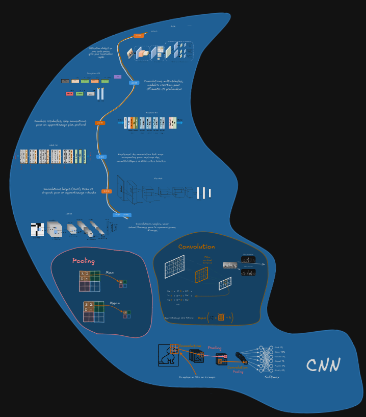

1. **Introduction aux CNN**

Les CNN sont des architectures spécialement conçues pour le traitement d'images et de vidéos.  
Ils prennent en compte la structure spatiale des pixels d'une image en regroupant les pixels de manière locale pour détecter des caractéristiques comme les contours et les textures.

2. **Opérations fondamentales**
- **Convolution** : Application de filtres (kernels) sur l'image pour détecter des motifs spécifiques (lignes, bords, textures).

Exemple : Un filtre vertical extrait les éléments verticaux d'une image.

- **Pooling** : Réduction de la taille des données en regroupant les pixels dans des zones.
  - **Max Pooling** : Prend le maximum de chaque zone.
  - **Average Pooling** : Prend la moyenne de chaque zone.
3. **Évolution des CNN dans le temps**
- **LeNet (années 1990)** : Créé par Yann LeCun, ce modèle a résolu le problème MNIST (reconnaissance de chiffres).
- **AlexNet (2012)** : Introduction de convolutions plus larges (11x11) et d'une architecture plus profonde.
- **VGG16** : Utilisation d'empilements de convolutions plus fines (3x3) pour capturer des détails complexes.
- **ResNet (2015)** : Ajout de couches résiduelles pour faciliter l'apprentissage de réseaux très profonds.
- **Inception et YOLO (2015)** : Détection d'objets et segmentation d'images.
4. **Applications des CNN**

Les CNN sont la base de nombreux systèmes de vision par ordinateur, comme la détection d'objets, la reconnaissance faciale, et la segmentation d'images.

5. **Conclusion**

Les CNN combinent convolution, pooling, et réseaux de neurones classiques pour produire des architectures robustes et performantes.  
Ils constituent une étape clé dans l'évolution des réseaux de neurones modernes.

## 12. RECURRENT NEURAL NETWORKS (RNN)

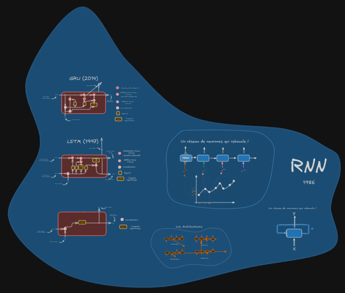

1. **Introduction aux RNN**

Les RNN sont conçus pour traiter des données séquentielles comme des séries temporelles ou des séquences de texte.  
Ils fonctionnent en "rebouclant" sur eux-mêmes, permettant à l'information des étapes précédentes d'influencer les prédictions actuelles.

2. **Architectures des RNN**
- **One-to-One** : Une entrée produit une sortie, idéal pour les séries temporelles simples.
- **One-to-Many** : Une entrée produit plusieurs sorties, utile pour générer des séquences comme des notes de musique.
- **Many-to-One** : Plusieurs entrées produisent une seule sortie, adapté pour des tâches comme l'analyse de sentiments.
- **Many-to-Many** : Plusieurs entrées produisent plusieurs sorties, utilisé pour des applications comme la traduction de textes.
3. **Problème des longues séquences**

Les RNN standards ont du mal à conserver l'information sur de longues séquences, ce qui limite leur efficacité.  
Ils ont tendance à oublier les données anciennes lorsque les séquences sont très longues.

4. **LSTM (Long Short-Term Memory)**

Introduit pour résoudre le problème des longues séquences, l'architecture LSTM intègre des mécanismes de mémoire à court et long terme.  
Cela permet de conserver des informations critiques sur de longues périodes, rendant les RNN plus puissants.

5. **GRU (Gated Recurrent Unit)**

Une variante simplifiée des LSTM, introduite en 2014, qui réduit la complexité tout en offrant des performances similaires dans de nombreux cas.

6. **Conclusion**

Les RNN, bien qu'anciens, restent une solution efficace pour les problèmes séquentiels.  
Cependant, ils ont été progressivement remplacés par des modèles plus récents et performants comme les Transformers, introduits en 2017.

## 13. TRANSFORMERS (2017)

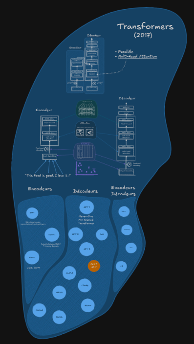

1. **Introduction aux Transformers**

Les transformers ont révolutionné le monde de l'intelligence artificielle en 2017.  
Contrairement aux RNN, ils traitent les données en parallèle, permettant un calcul rapide et efficace.  
Ils sont à la base des modèles modernes comme ChatGPT, les générateurs d'images, et bien plus.

2. **Structure du Transformer**

Un transformer est composé de deux parties principales :

- **Encoders** : Analysent les données d'entrée.
- **Decoders** : Génèrent les données de sortie.

Chaque partie repose sur trois éléments clés :

- **Embeddings** : Représentent les mots ou données dans un espace vectoriel pour capturer leur sens et leur contexte.
- **Multi-Head Attention** : Analyse les relations entre chaque mot ou élément, en créant plusieurs perspectives (têtes) pour identifier les connexions.
- **Feed-Forward Neural Networks** : Effectuent les calculs nécessaires pour transformer les données.
3. **Exemple d'application**

Phrase d'entrée : "This food is good, I love it."

- L'embedding positionne chaque mot dans un espace vectoriel selon son contexte.
- Le mécanisme d'attention analyse les relations logiques entre les mots.
- Les feed-forward networks transforment les résultats pour produire une sortie structurée.

Ce processus est particulièrement utile pour la traduction, la génération de texte, ou l'analyse de sentiments.

4. **Types de Transformers**
- **Encodeurs** : Exemples célèbres incluent BERT et ses variantes comme CamemBERT (version française), RoBERTa, et ALBERT.

Ces modèles encodent des données complexes en vecteurs pour des tâches comme la classification ou la régression.

- **Décodeurs** : Exemples comme GPT (Generative Pre-Trained Transformer). GPT-1, GPT-2, GPT-3, et ChatGPT sont des modèles emblématiques utilisés pour générer du texte.
- **Encodeurs-Décodeurs** : Modèles hybrides comme T5 et UL2, capables d'analyser et de générer des données.
5. **Avantages des Transformers**
- Parallélisation des calculs pour une grande efficacité.
- Attention multi-têtes pour capturer les relations complexes entre les données.
- Capacité à travailler avec des données séquentielles et contextuelles.
6. **Conclusion**

Les transformers ont marqué une avancée majeure dans l'IA et restent à la base des modèles modernes les plus performants.  
Ils combinent puissance, flexibilité, et scalabilité pour répondre à des besoins variés.

## 14. GANS ET MODÈLES DE DIFFUSION

[figure not shown]

1. **Introduction aux GANs (2014)**

Les GANs (Generative Adversarial Networks) ont été introduits par Ian Goodfellow.  
Ils reposent sur deux réseaux de neurones en compétition :

- **Générateur** : Crée des images à partir de bruit aléatoire.
- **Discriminateur** : Classifie les images comme vraies ou générées.

Le générateur apprend à créer des images réalistes en trompant le discriminateur.  
Ils ont été utilisés pour générer des visages, des personnages de manga, et plus encore.

2. **Limites des GANs**

Les GANs ne prennent pas de prompts en entrée.  
Ils sont spécialisés dans un type d'image spécifique et ne permettent pas de personnalisation directe.

3. **Modèles de Diffusion**

Les modèles de diffusion comme **DALL-E** et **Stable Diffusion** s'appuient sur des encodeurs et décodeurs.

- **DALL-E** : Utilise un encodeur pour traiter un prompt (texte), combiné à des embeddings d'images (CLIP).
- **Stable Diffusion** : Passe par des étapes itératives, générant une image à partir d'un bruit aléatoire en affinant progressivement les détails.

Ils permettent une personnalisation poussée grâce à l'utilisation de prompts.

4. **Mécanisme de Diffusion**
- Départ d'une matrice de bruit aléatoire.
- Itérations successives via un réseau UNet pour affiner l'image.
- Décodage final pour obtenir l'image générée.

Ces modèles sont particulièrement populaires dans des outils comme **MidJourney** (bien que son architecture ne soit pas entièrement publique).

5. **Applications des GANs et Modèles de Diffusion**
- Génération d'images réalistes à partir de bruit.
- Création artistique (exemple : DALL-E et MidJourney).
- Réduction de bruit et restauration d'images.
6. **Conclusion**

Les GANs et modèles de diffusion sont des outils puissants pour la génération d'images.  
Ils combinent des principes fondamentaux des réseaux de neurones avec des mécanismes d'apprentissage avancés pour produire des résultats impressionnants.

## 15. AUTO-ENCODEURS

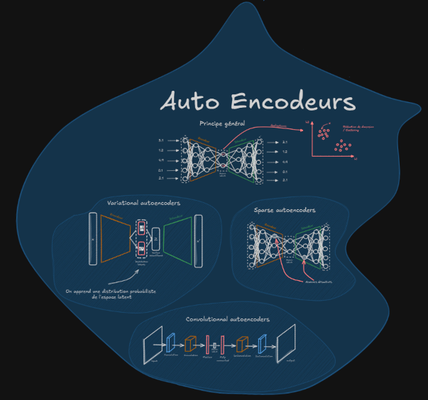

1. **Principe Général**

Les auto-encodeurs sont des réseaux de neurones conçus pour reconstruire en sortie la même donnée que celle fournie en entrée.  
Entre les couches d'entrée et de sortie, un espace latent est créé, de plus petite dimension, représentant les données de manière compressée.  
Applications :

- Réduction de dimension.
- Clustering.
- Détection d'anomalies.
2. **Variationnel Auto-Encodeurs (VAE)**

Contrairement aux auto-encodeurs classiques, les VAE apprennent une distribution probabiliste dans l'espace latent.  
Les paramètres (moyenne, variance) d'une distribution comme une loi normale sont optimisés.  
Applications :

- Génération de données synthétiques.
- Clustering probabiliste.
3. **Sparse Auto-Encodeurs**

Ces auto-encodeurs introduisent une contrainte de parcimonie.  
Certaines neurones sont désactivées pour forcer le réseau à apprendre une représentation plus compacte.  
Utilisés pour des tâches où seules certaines caractéristiques sont essentielles.

4. **Convolutional Auto-Encodeurs**

Ces modèles sont adaptés au traitement d'images.  
Les couches convolutionnelles sont utilisées pour encoder et reconstruire des images tout en préservant leurs caractéristiques essentielles.  
Applications :

- Compression d'images.
- Denoising (réduction de bruit sur des images).

Les auto-encodeurs sont des outils polyvalents pour extraire des représentations utiles des données tout en les compressant de manière efficace.

## 16. Apprentissage par Renforcement et Algorithmes Génétiques

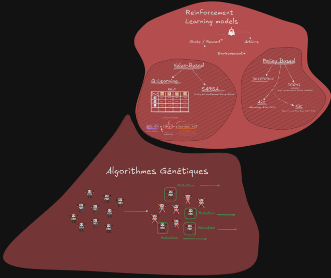

### Modèles d'Apprentissage par Renforcement

1. **Structure Générale**
   - Un **agent** interagit avec un **environnement** en effectuant des actions.
   - L'agent reçoit un **état** et une **récompense** pour chaque action.
   - Objectif : Maximiser les récompenses cumulées.
2. **Méthodes Value-Based**
   - Exemple : **Q-Learning**
     - Crée une matrice pour prédire la valeur de chaque action dans un état donné.
   - Exemple : **SARSA**
     - Similaire à Q-Learning mais tient compte des actions futures probables.
3. **Méthodes Policy-Based**
   - Exemple : **Reinforce**
     - Apprend directement une politique pour choisir les actions.
   - Algorithmes avancés : **A2C**, **A3C**, **DDPG**, etc.

### Algorithmes Génétiques

1. **Principe Général**
   - Basé sur l'évolution naturelle : Sélection, Mutation, Croisement.
   - Initialisation d'une population aléatoire.
2. **Étapes Principales**
   - **Évaluation** : Mesurer la performance de chaque modèle.
   - **Sélection** : Garder les meilleurs modèles (basés sur leurs performances).
   - **Mutation** : Modifier légèrement les paramètres pour explorer de nouvelles solutions.
   - **Croisement** : Combiner les caractéristiques des meilleurs modèles.
3. **Applications**
   - Utilisé pour des tâches complexes comme la conduite autonome ou l'optimisation de systèmes.
   - Approche innovante pour des environnements très dynamiques.